# A/B-тестирование: стоит ли переносить игровой барьер?

## Cookie Cats · control / treatment

**Бизнес-задача:** выяснить, помогает ли перенос первого игрового барьера с 30-го на 40-й уровень удерживать новых игроков.

**Маршрут:** данные → EDA → H₀/H₁ → выбор теста → p-value → доверительный интервал → решение для бизнеса.

Это учебный ретроспективный разбор готового эксперимента. Основную метрику для этого проекта выбираем по бизнес-вопросу: **retention_7**, то есть долю игроков, вернувшихся на 7-й день после установки. Мы не утверждаем, что она была заранее зарегистрирована авторами эксперимента. В реальном тесте метрику, размер выборки, срок и правила решения фиксируют до запуска.

## 1. Данные и дизайн эксперимента

Используем публичный набор Cookie Cats из учебного проекта DataCamp. CSV сохранён локально; источник, версия и контрольная сумма находятся в файлах data/README.md и data/source.json. В [карточке датасета](https://www.kaggle.com/datasets/mursideyarkin/mobile-games-ab-testing-cookie-cats) описано случайное назначение игроков в варианты.

| Поле | Значение |
| --- | --- |
| userid | Идентификатор игрока; единица рандомизации и анализа |
| version | gate_30 — control; gate_40 — treatment |
| sum_gamerounds | Количество сыгранных раундов; по карточке датасета — за первые 14 дней |
| retention_1 | Возврат на 1-й день, True / False; только описательная метрика |
| retention_7 | Возврат на 7-й день, True / False; основная метрика |

Игровой барьер требует ожидания или покупки, чтобы продолжить прохождение. Идея изменения: дать игроку больше времени до первой паузы. Отсрочка может как улучшить вовлечение, так и ухудшить возвращаемость — поэтому проверяем изменение в обе стороны.

Анализируем **всех назначенных игроков** по исходной группе, включая тех, кто не дошёл до барьера или не сыграл ни одного раунда. Отбор по действиям после назначения может исказить эффект изменения.

```
Matplotlib is building the font cache; this may take a moment.
```

```
Python: 3.9.6
Библиотеки: {'numpy': '2.0.2', 'pandas': '2.2.3', 'scipy': '1.13.1', 'statsmodels': '0.14.4', 'matplotlib': '3.9.4'}
```

|  | userid | version | sum_gamerounds | retention_1 | retention_7 |
| --- | --- | --- | --- | --- | --- |
| 0 | 116 | gate_30 | 3 | False | False |
| 1 | 337 | gate_30 | 38 | True | False |
| 2 | 377 | gate_40 | 165 | True | False |
| 3 | 483 | gate_40 | 1 | False | False |
| 4 | 488 | gate_40 | 179 | True | True |

```
Размер: 90,189 строк × 5 столбцов
```

## 2. EDA: качество данных и сравнение групп

Сначала проверим полноту и структуру данных: пропуски, повторные строки, повторные идентификаторы и допустимые значения. Ничего не удаляем автоматически: ошибки входных данных должны остановить анализ и потребовать разбирательства.

|  | Проверка | Количество |
| --- | --- | --- |
| 0 | Пропуски во всех полях | 0 |
| 1 | Полные дубликаты | 0 |
| 2 | Повторные userid | 0 |
| 3 | Отрицательное число раундов | 0 |

|  | Тип данных |
| --- | --- |
| userid | int64 |
| version | object |
| sum_gamerounds | int64 |
| retention_1 | bool |
| retention_7 | bool |

```
Проверки пройдены. Строк удалено: 0.
```

| group | users | retained_d1 | retained_d7 | retention_d1 | retention_d7 | mean_rounds | median_rounds | share |
| --- | --- | --- | --- | --- | --- | --- | --- | --- |
| control | 44,700 | 20,034 | 8,502 | 44.82% | 19.02% | 52.46 | 17 | 49.56% |
| treatment | 45,489 | 20,119 | 8,279 | 44.23% | 18.20% | 51.30 | 16 | 50.44% |

| group | count | mean | std | min | 50% | 90% | 99% | max |
| --- | --- | --- | --- | --- | --- | --- | --- | --- |
| control | 44700.0000 | 52.4563 | 256.7164 | 0.0000 | 17.0000 | 135.0000 | 493.0000 | 49854.0000 |
| treatment | 45489.0000 | 51.2988 | 103.2944 | 0.0000 | 16.0000 | 134.0000 | 492.1200 | 2640.0000 |

|  | userid | version | sum_gamerounds | retention_1 | retention_7 | group |
| --- | --- | --- | --- | --- | --- | --- |
| 57702 | 6390605 | gate_30 | 49854 | 0 | 1 | control |
| 7912 | 871500 | gate_30 | 2961 | 1 | 1 | control |
| 29417 | 3271615 | gate_40 | 2640 | 1 | 0 | treatment |

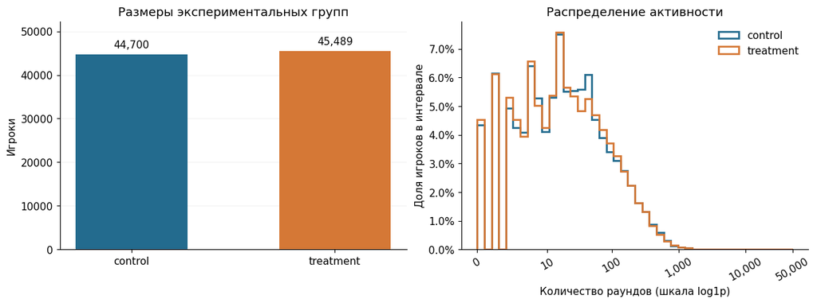

В активности есть длинный правый хвост: среднее чувствительно к очень большим значениям. Максимальную запись стоит проверить по журналам событий. В этом проекте её сохраняем: основная метрика бинарная, и число раундов не увеличивает вес игрока в расчёте удержания. Логарифмическая шкала нужна только для отображения; исходные данные не преобразуем и не фильтруем.

Различия в количестве раундов и retention_1 описываем без отдельных проверок значимости. Это метрики после воздействия, поэтому их близость или различие не доказывает качество рандомизации.

### Проверка соотношения групп — SRM

Для диагностической проверки принимаем **плановое распределение 50 / 50**. Это допущение проекта: протокол с заданной долей трафика в CSV отсутствует. Проверяем χ²-тестом согласия, совместимы ли размеры групп с таким распределением. Для этой диагностики используем порог 0,01.

SRM проверяет только численность групп. Даже высокий p-value не доказывает, что рандомизация и сбор событий работали без ошибок.

При сигнале SRM дальнейшие расчёты сохраняем как учебные и предварительные; окончательный причинный вывод откладываем до проверки плановых долей и логов.

```
SRM: χ² = 6.9024; p-value = 0.0086
Есть сигнал SRM при допущении 50/50. Проверьте плановые доли и сбор данных.
Ниже — предварительные расчёты; окончательный причинный вывод делать рано.
```

## 3. Формулировка H₀ / H₁

Пусть p_control и p_treatment — вероятности возврата на 7-й день в соответствующих вариантах. Интересующий эффект:

**Δ = p_treatment − p_control.**

- **H₀: Δ = 0.** Перенос барьера не меняет вероятность возврата на 7-й день.
- **H₁: Δ ≠ 0.** Перенос барьера меняет эту вероятность.
- Уровень значимости основной проверки **α = 0,05**.
- Альтернатива двусторонняя: важны и улучшение, и ухудшение.

При p-value < α отвергаем H₀. Иначе оснований отвергнуть H₀ недостаточно — это не доказательство равенства вариантов.

Одна основная метрика означает одну основную проверку. Retention_1 остаётся описательной: мы не выбираем «удачный» результат из нескольких тестов. SRM — отдельная проверка качества эксперимента, а не поиск продуктового эффекта.

## 4. Почему z-тест двух долей

Результат для каждого игрока равен 0 или 1; сравниваем доли успехов в двух независимых группах. Для большой выборки подходит [двухвыборочный z-тест долей](https://www.statsmodels.org/stable/generated/statsmodels.stats.proportion.proportions_ztest.html).

Проверим, что ожидаемых успехов и неуспехов при H₀ достаточно для нормального приближения. Нормальность исходной бинарной метрики не требуется.

Предположения: независимость игроков, случайное назначение, отсутствие влияния групп друг на друга и полное окно наблюдения до 7-го дня для каждого игрока. Уникальность идентификаторов проверяется по CSV; остальные условия полностью подтвердить без протокола и журналов эксперимента нельзя.

Под H₀ используем объединённую долю p_pool:

**z = (p̂_treatment − p̂_control) / √[p_pool × (1 − p_pool) × (1/n_treatment + 1/n_control)].**

|  | Ожидаемые возвраты при H0 | Ожидаемые невозвраты при H0 |
| --- | --- | --- |
| control | 8317.0974 | 36382.9026 |
| treatment | 8463.9026 | 37025.0974 |

```
Control:   8,502 / 44,700 = 19.0201%
Treatment: 8,279 / 45,489 = 18.2000%
z = -3.1644; p-value = 0.001554
Разница: -0.8201 п.п.; относительное изменение: -4.31%
При выполнении предпосылок H0 отвергаем.
Это номинальный p-value: сигнал SRM ещё не объяснён.
```

**Как понимать p-value.** Если H₀ верна и предположения теста выполнены, p-value — вероятность получить столь же или более экстремальную тестовую статистику в любую сторону. Это не вероятность истинности H₀ и не вероятность того, что результат «случайный».

Процентные пункты и проценты отвечают на разные вопросы: разница долей, умноженная на 100, — это **п.п.**; разница, делённая на долю control, — **относительное изменение**.

## 5. Доверительный интервал

Для эффекта Δ строим 95%-й [интервал Ньюкомба на основе интервалов Уилсона](https://www.statsmodels.org/stable/generated/statsmodels.stats.proportion.confint_proportions_2indep.html). Для каждой отдельной группы на графике используем интервал Уилсона. Основной вывод о разнице делаем по **интервалу Δ**, а не по пересечению интервалов отдельных групп.

Это частотный интервал: при многократном повторении процедуры примерно 95% таких интервалов покрывали бы истинную разницу. Он не означает, что фиксированный параметр с вероятностью 95% лежит внутри уже рассчитанных границ.

Z-тест и интервал Ньюкомба используют разные приближения; интервал не является точной инверсией выбранного теста. Здесь проверим, что их выводы согласуются.

```
95% ДИ разницы treatment − control: [-1.3282; -0.3121] п.п.
Ноль входит в интервал: False
```

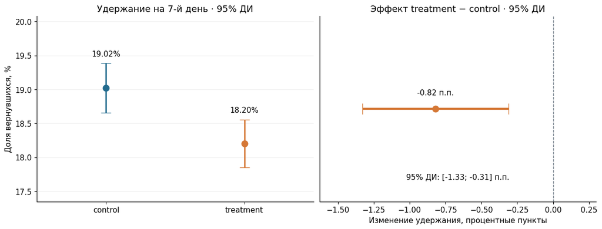

## 6. Проверка расчётов

Сверим z-статистику с формулой и с χ²-тестом независимости для таблицы 2 × 2 **без поправки Йейтса**: в этой постановке χ² = z². Это проверка вычислений на тех же данных, а не новое независимое подтверждение эффекта.

```
Формула, z-тест, χ²-тест и направление доверительного интервала согласуются.
```

## 7. Вывод для бизнеса

Переведём эффект в число вернувшихся игроков на 10 000 новых установок. Это масштабирование разницы вероятностей при сопоставимой аудитории, **не прогноз случайного числа возвратов** в конкретной будущей когорте. Интервал показывает неопределённость средней разницы, а не прогнозный интервал.

Денежную оценку не рассчитываем: в CSV нет выручки, платежей, LTV или стоимости внедрения. Порог минимального полезного эффекта также не задан владельцем продукта.

Вывод для бизнеса: Cookie Cats

**Рекомендация:** Сохранить текущий вариант control и отложить внедрение treatment. Сначала проверить плановые доли трафика, рандомизацию и полноту событий: обнаружен сигнал SRM при допущении 50/50.

| Показатель | Результат |
| --- | --- |
| Игроков в control / treatment | 44,700 / 45,489 |
| Удержание на 7-й день: control | 19.02% |
| Удержание на 7-й день: treatment | 18.20% |
| Разница treatment − control | -0.820 п.п. |
| Относительное изменение | -4.31% |
| Номинальный двусторонний p-value | 0.001554 |
| 95% ДИ разницы, Ньюкомб | [-1.328; -0.312] п.п. |
| Эффект на 10 000 новых игроков | -82 возвратов на 7-й день |
| 95% ДИ среднего эффекта на 10 000 | [-133; -31] |

При выполнении предпосылок номинальный z-тест указывает на снижение удержания в treatment. Из-за неразобранного сигнала SRM этот вывод предварительный: наблюдаемую разницу пока нельзя уверенно приписывать переносу барьера. Основная проверка — z-тест двух независимых долей, α = 0.05. Все 90,189 игроков сохранены в анализе по назначенной группе.

Масштабирование на 10 000 предполагает сопоставимую аудиторию и не является прогнозным интервалом для фактического числа возвратов.

Результат относится к удержанию на 7-й день в этой выборке. Выручка и долгосрочная ценность игрока не измерены. Нет дат назначения, журналов событий и протокола: полноту окна наблюдения, независимость и корректность рандомизации нельзя полностью проверить. SRM при допущении 50/50: p-value = 0.0086; есть диагностический сигнал при пороге 0,01. Если плановые доли были другими, диагностику следует пересчитать по протоколу; подбирать доли по наблюдаемым размерам групп нельзя. До этой проверки p-value и доверительный интервал эффекта рассматриваем как условные на корректность данных.

Следующий шаг: проверить телеметрию и изучить причины снижения удержания; новые варианты проверять отдельным экспериментом с заранее выбранной основной метрикой, минимальным полезным эффектом, размером выборки и сроком.

## 8. Ограничения и что показать на защите

- Исходная рандомизация описана в карточке, но журнал назначений отсутствует. Причинная интерпретация условна на корректность дизайна и сбора данных. Сигнал SRM требует проверить плановые доли, назначение и потерю событий; простое выравнивание размеров групп удалением игроков проблему не исправляет.
- В данных нет дат: нельзя проверить сезонность, длительность теста, преждевременную остановку и полное семидневное наблюдение каждого игрока.
- Нет характеристик до эксперимента: нельзя проверить баланс по каналам, устройствам и странам. Не используем метрики после назначения для такой проверки.
- Величина p-value не показывает размер или денежную ценность эффекта: для этого нужны разница долей, доверительный интервал и бизнес-метрики.
- Вывод по 7-му дню нельзя автоматически переносить на месячное удержание и прибыль.

**Краткий рассказ о работе:** сформулирован вопрос о переносе игрового барьера; проверены данные и численность групп; выбрана одна основная бинарная метрика; проведён двусторонний z-тест двух долей; рассчитан интервал разницы; эффект переведён в игроков на 10 000 установок и сформулировано решение.

```
Сохранены results.json, group_summary.csv, business_summary.md и два графика.
```

## Источники

1. [Карточка Cookie Cats](https://www.kaggle.com/datasets/mursideyarkin/mobile-games-ab-testing-cookie-cats): описание полей, групп и происхождения данных.
2. [Фиксированная копия CSV](https://github.com/sevvalnrdede/AB-Test-Analysis-Mobile-Game-Gate-Placement/blob/ab9c6de8a38bb36fa6a155ca93bb07dab292c632/cookie_cats.csv): фактический источник локального файла.
3. [Statsmodels: proportions_ztest](https://www.statsmodels.org/stable/generated/statsmodels.stats.proportion.proportions_ztest.html).
4. [Statsmodels: confint_proportions_2indep](https://www.statsmodels.org/stable/generated/statsmodels.stats.proportion.confint_proportions_2indep.html).

Текст анализа, код, графики и выводы в этом проекте рассчитаны самостоятельно; чужие ноутбуки для получения результата не использовались.